# Analysis of Activity from Monitoring Devices

## Introduction

It is now possible to collect a large amount of data about personal movement using activity monitoring devices such as a [Fitbit](http://www.fitbit.com/de), [Nike Fuelband](http://www.nike.com/us/en_us/c/nikeplus-fuelband), or [Jawbone Up](https://jawbone.com/up). These type of devices are part of the “quantified self” movement – a group of enthusiasts who take measurements about themselves regularly to improve their health, to find patterns in their behavior, or because they are tech geeks. But these data remain under-utilized both because the raw data are hard to obtain and there is a lack of statistical methods and software for processing and interpreting the data.

This assignment makes use of data from a personal activity monitoring device. This device collects data at 5 minute intervals through out the day. The data consists of two months of data from an anonymous individual collected during the months of October and November, 2012 and include the number of steps taken in 5 minute intervals each day.

## Data

Dataset: [Activity monitoring data](https://d396qusza40orc.cloudfront.net/repdata%2Fdata%2Factivity.zip) [52K]

The variables included in this dataset are:

- **steps**: Number of steps taking in a 5-minute interval (missing values are coded as `NA`)
- **date**: The date on which the measurement was taken in YYYY-MM-DD format
- **interval**: Identifier for the 5-minute interval in which measurement was taken

The dataset is stored in a comma-separated-value (CSV) file and there are a total of 17,568 observations in this dataset.

## Assingment

This assignment will be described in multiple parts. You will need to write a report that answers the questions detailed below. Ultimately, you will need to complete the entire assignment in a single R markdown document that can be processed by knitr and be transformed into an HTML file.

Throughout your report make sure you always include the code that you used to generate the output you present. When writing code chunks in the R markdown document, always use `echo = TRUE` so that someone else will be able to read the code. This assignment will be evaluated via peer assessment so it is essential that your peer evaluators be able to review the code for your analysis.

For the plotting aspects of this assignment, feel free to use any plotting system in R (i.e., base, lattice, ggplot2)

Fork/clone the GitHub repository created for this assignment. You will submit this assignment by pushing your completed files into your forked repository on GitHub. The assignment submission will consist of the URL to your GitHub repository and the SHA-1 commit ID for your repository state.

NOTE: The GitHub repository also contains the dataset for the assignment so you do not have to download the data separately.

## Analysis

### Step 1: Load Libraries and dataset

Load the data (i.e. `read.csv()`).

```r
#### 1 Load libraries and dataset

# load libraries
library(ggplot2)  # plotting data
library(plyr)  # transform data

# to print big numbers
options(scipen = 20)

# read data
data <- read.csv(file = "activity.csv", header = TRUE, stringsAsFactors = FALSE)

# display structure of the data
str(data)
```

```
## 'data.frame':    17568 obs. of  3 variables:
##  $ steps   : int  NA NA NA NA NA NA NA NA NA NA ...
##  $ date    : chr  "2012-10-01" "2012-10-01" "2012-10-01" "2012-10-01" ...
##  $ interval: int  0 5 10 15 20 25 30 35 40 45 ...
```

### Step 2: Pre-Process / Transform the data

Process/transform the data (if necessary) into a format suitable for your analysis.

```r
#### 2 Pre-Process / Transform the data

# transform to Date data type
data$date <- as.Date(data$date, format = "%Y-%m-%d")

# display structure of the data
str(data)
```

```
## 'data.frame':    17568 obs. of  3 variables:
##  $ steps   : int  NA NA NA NA NA NA NA NA NA NA ...
##  $ date    : Date, format: "2012-10-01" "2012-10-01" ...
##  $ interval: int  0 5 10 15 20 25 30 35 40 45 ...
```

### Step 3: Answer questions

#### What is mean total number of steps taken per day?

For this part of the assignment, you can ignore the missing values in the dataset.

```r
#### 3 Answer questions

#### What is mean total number of steps taken per day?

# summary of the data
summary(data)
```

```
##      steps            date               interval
##  Min.   :  0.0   Min.   :2012-10-01   Min.   :   0
##  1st Qu.:  0.0   1st Qu.:2012-10-16   1st Qu.: 589
##  Median :  0.0   Median :2012-10-31   Median :1178
##  Mean   : 37.4   Mean   :2012-10-31   Mean   :1178
##  3rd Qu.: 12.0   3rd Qu.:2012-11-15   3rd Qu.:1766
##  Max.   :806.0   Max.   :2012-11-30   Max.   :2355
##  NA's   :2304
```

```r
# mean = 37.38 median = 0

# calculate the mean and the median we will use them to plot vertical lines
# in the histogram
(mean.data <- mean(data$steps, na.rm = TRUE))
```

```
## [1] 37.38
```

```r
(median.data <- median(data$steps, na.rm = TRUE))
```

```
## [1] 0
```

```
## stat_bin: binwidth defaulted to range/30. Use 'binwidth = x' to adjust this.
```

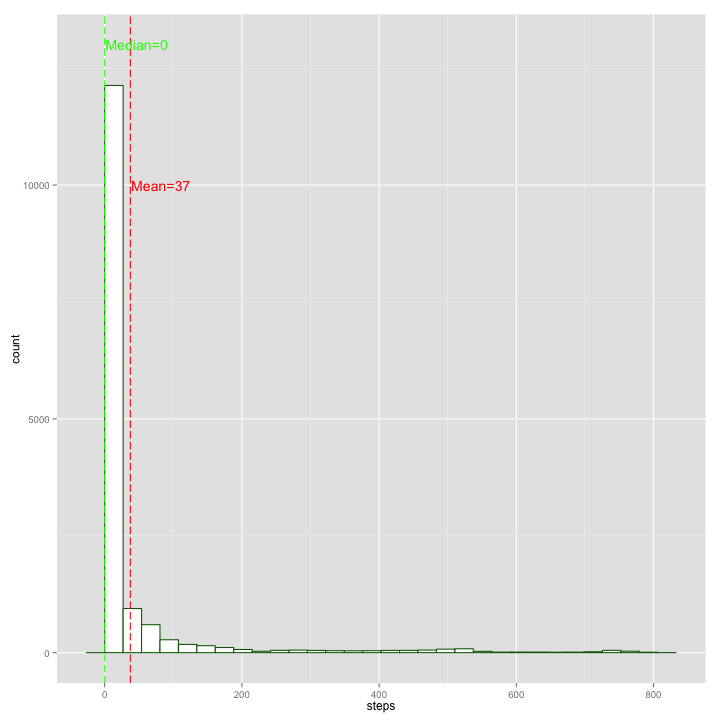

```r
# plot histogram of steps adding vertical lines for mean and median
ggplot(data, aes(x = steps)) + geom_histogram(colour = "darkgreen", fill = "white") +
    geom_vline(xintercept = mean.data, col = "red", show_guide = TRUE, linetype = "longdash") +
    geom_vline(xintercept = median.data, col = "green", show_guide = TRUE, linetype = "longdash") +
    annotate("text", x = median.data + 1, y = 13000, label = paste(c("Median="),
        round(median.data, 0), sep = ""), hjust = 0, col = "green") + annotate("text",
    x = mean.data + 1, y = 10000, label = paste(c("Mean="), round(mean.data,
        0), sep = ""), hjust = 0, col = "red")
```

#### What is the average daily activity pattern?

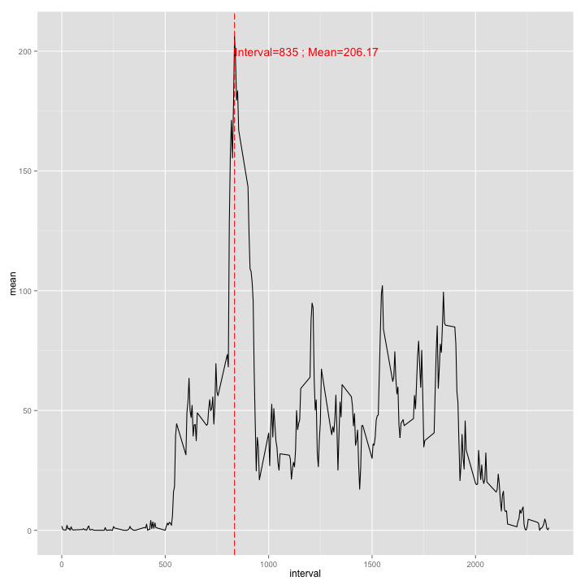

```r
#### What is the average daily activity pattern?

# average the number of steps by interval for all days
agg.data <- ddply(data, .(interval), summarize, mean = mean(steps, na.rm = TRUE))

# get the interval where the maximum mean value is and the value of the
# average number of steps
interval.max.mean <- agg.data$interval[which(agg.data$mean == max(agg.data$mean))]
value.max.mean <- round(max(agg.data$mean), 2)

# plot average number of step by interval for all days with vertical line
# showing the maximum value
ggplot(agg.data, aes(x = interval, y = mean)) + geom_line(type = "l") + geom_vline(xintercept = interval.max.mean,
    col = "red", show_guide = TRUE, linetype = "longdash") + annotate("text",
    x = interval.max.mean + 1, y = 200, label = paste(c("Interval="), round(interval.max.mean,
        0), " ; Mean=", value.max.mean, sep = ""), hjust = 0, col = "red")
```